# What external factors are there in building a more successful startup?

Timothy Nguyen & Jacob Yang

5/6/2021

## Why is it important?

- Startups are full of promise and excitement, but the flip side is, they’re also full of risk and uncertainty. There are a lot of great ideas out there that somehow never get off the ground, and, conversely, there are plenty of questionable ones that become massive successes.
- In addition to a good idea, there are many factors that influence a startup’s success, and understanding and leveraging these factors will help a startup get further along the road to success.
- In this project, we will focus on some external factors that may affect a startup’s developement:
  - Category of industries, locations, investors

## Why is it important?

- If you’re looking to build a startup, understanding where to begin your startup may be important based off the industry you’re in.
- Successful can mean many things. It can mean being operated and become a series C or higher startup. Maybe you want to build a company that IPO or accquired. Are there specific industries or locations where you can find your success?
- What investors could be important to your business?

## Datasets (Companies Side)

- company name, funding_total_usd, status, country_code, state_code, city, funding_rounds, last_funding_year

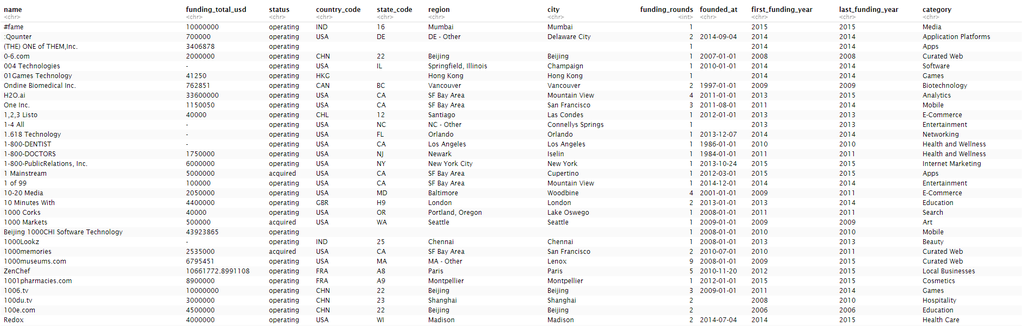

## Datasets (Investors side)

- investor_name, state_code, category (industry), funded_Year, raised_amount_usd

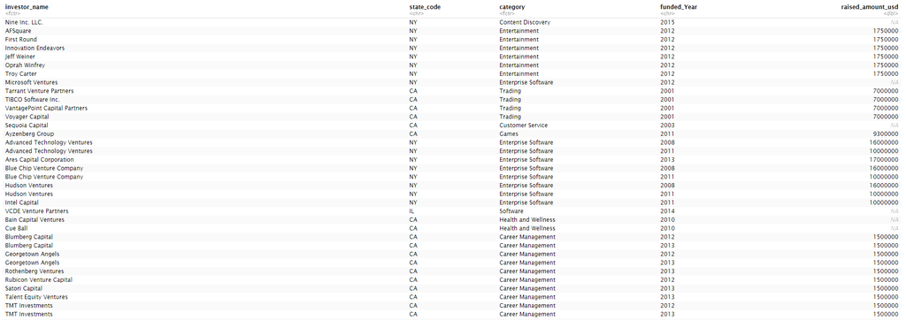

## Startups locations - Companies.R

[figure not shown]

## Investor Interactive plots - Investors.R

```
##
## Listening on http://127.0.0.1:3599
```

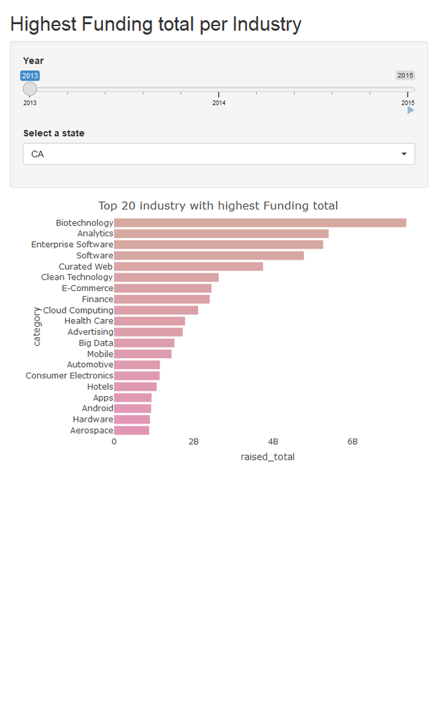

## Resource

- https://github.com/notpeter/crunchbase-data